# Overview

This Jupyter notebook documents an attempt to create a Machine Learning solution for the Kaggle "Titanic: Machine Learning from Disaster" competition.

Let's take a brief look at the data:

```python
# import necessary dependencies
import pandas as pd
import numpy as np
%matplotlib inline
import matplotlib.pyplot as plt
import matplotlib as mpl
import seaborn as sns
sns.set()

# get the training and test set
train_set = pd.read_csv('train.csv')
test_set = pd.read_csv('test.csv')

# get a feel of type of data
train_set.head()
```

|  | PassengerId | Survived | Pclass | Name | Sex | Age | SibSp | Parch | Ticket | Fare | Cabin | Embarked |
| --- | --- | --- | --- | --- | --- | --- | --- | --- | --- | --- | --- | --- |
| 0 | 1 | 0 | 3 | Braund, Mr. Owen Harris | male | 22.0 | 1 | 0 | A/5 21171 | 7.2500 | NaN | S |
| 1 | 2 | 1 | 1 | Cumings, Mrs. John Bradley (Florence Briggs Th... | female | 38.0 | 1 | 0 | PC 17599 | 71.2833 | C85 | C |
| 2 | 3 | 1 | 3 | Heikkinen, Miss. Laina | female | 26.0 | 0 | 0 | STON/O2. 3101282 | 7.9250 | NaN | S |
| 3 | 4 | 1 | 1 | Futrelle, Mrs. Jacques Heath (Lily May Peel) | female | 35.0 | 1 | 0 | 113803 | 53.1000 | C123 | S |
| 4 | 5 | 0 | 3 | Allen, Mr. William Henry | male | 35.0 | 0 | 0 | 373450 | 8.0500 | NaN | S |

# Preprocessing

First we'll need to split the dataset into feature and target sets.

```python
def splitTitanicSet(train_set):
    y = train_set['Survived']
    X = train_set.drop('Survived', axis=1)
    return (X, y)

X, y = splitTitanicSet(train_set)
```

Then let's get an overview of the features and at how many null values there are in each feature:

```python
train_set.describe()
```

|  | PassengerId | Survived | Pclass | Age | SibSp | Parch | Fare |
| --- | --- | --- | --- | --- | --- | --- | --- |
| count | 891.000000 | 891.000000 | 891.000000 | 714.000000 | 891.000000 | 891.000000 | 891.000000 |
| mean | 446.000000 | 0.383838 | 2.308642 | 29.699118 | 0.523008 | 0.381594 | 32.204208 |
| std | 257.353842 | 0.486592 | 0.836071 | 14.526497 | 1.102743 | 0.806057 | 49.693429 |
| min | 1.000000 | 0.000000 | 1.000000 | 0.420000 | 0.000000 | 0.000000 | 0.000000 |
| 25% | 223.500000 | 0.000000 | 2.000000 | 20.125000 | 0.000000 | 0.000000 | 7.910400 |
| 50% | 446.000000 | 0.000000 | 3.000000 | 28.000000 | 0.000000 | 0.000000 | 14.454200 |
| 75% | 668.500000 | 1.000000 | 3.000000 | 38.000000 | 1.000000 | 0.000000 | 31.000000 |
| max | 891.000000 | 1.000000 | 3.000000 | 80.000000 | 8.000000 | 6.000000 | 512.329200 |

```python
train_set.info()
```

```
<class 'pandas.core.frame.DataFrame'>
RangeIndex: 891 entries, 0 to 890
Data columns (total 12 columns):
PassengerId    891 non-null int64
Survived       891 non-null int64
Pclass         891 non-null int64
Name           891 non-null object
Sex            891 non-null object
Age            714 non-null float64
SibSp          891 non-null int64
Parch          891 non-null int64
Ticket         891 non-null object
Fare           891 non-null float64
Cabin          204 non-null object
Embarked       889 non-null object
dtypes: float64(2), int64(5), object(5)
memory usage: 83.6+ KB
```

We will drop the "Cabin" feature because there are so many null values. In addition, 'Name', 'Ticket' and 'PassengerId' can be dropped because they should not have an impact on the result.

To do this, we create a transformer, in Scikit-Learn style, that converts a Pandas Data Frame to a Numpy 2d array at the same time and that we can reuse:

```python
from sklearn.base import BaseEstimator, TransformerMixin

class DataFrameSelector(BaseEstimator, TransformerMixin):
    def __init__(self, attribute_names):
        self.attribute_names = attribute_names
    def fit(self, X, y=None):
        return self
    def transform(self, X):
        return X[self.attribute_names].values
```

We can also look more closely at the "Fare" and "Pclass" attributes, to see if they both have the same correlation with survival rate and thus one could be dropped.

The ticket class does correlate with the fare paid (as can be seen from the graph below). However, we also see that the fare seems to have an impact on the survival rate within each ticket class (people who paid the lowest fare seem to have the lowest survival rate irrespective of what ticket class they bought). Therefore, it could be useful to keep both attributes.

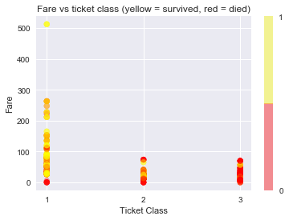

```python
# define colormap
from matplotlib import colors
cmap = colors.ListedColormap(['red', 'yellow'])

# plot scatter plot
ax = plt.axes()
plt.scatter(train_set['Pclass'], train_set['Fare'], c=train_set['Survived'], cmap=cmap, alpha=0.4)
ax.xaxis.set_major_locator(plt.FixedLocator([1,2,3]))
plt.colorbar(ticks=range(2))
plt.ylabel('Fare')
plt.xlabel('Ticket Class')
plt.title('Fare vs ticket class (yellow = survived, red = died)');
```

Now we can drop the attributes that we don't want to use in training the classifier:

```python
data_frame_selector = DataFrameSelector(['Pclass', 'Sex', 'Age', 'SibSp', 'Parch', 'Fare', 'Embarked'])
X = data_frame_selector.transform(X)
```

Next we need to take care of: 1) filling in the missing values (especially in the "Age" attribute) 2) converting categorical text attributes in to numbers because machine learning algorithms prefer numbers over text 3) feature scaling numerical attributes because machine learning algorithms often don't work well on numerical attributes with very different scales

Let's put all this into a pipeline so we can automatically complete the process later:

```python
from sklearn.pipeline import Pipeline
from sklearn.pipeline import FeatureUnion
from sklearn.preprocessing import Imputer
from sklearn.preprocessing import LabelEncoder
from sklearn.preprocessing import StandardScaler

# split titanic set into feature and target sets
def splitTitanicSet(titanic_set):
    y = titanic_set['Survived']
    X = titanic_set.drop('Survived', axis=1)
    return (X, y)

num_attribs = ['Age', 'SibSp', 'Parch', 'Fare'] # numerical attributes
cat_attribs = ['Pclass', 'Sex', 'Embarked'] # categorical attributes

num_pipeline = Pipeline([
    ('selector', DataFrameSelector(num_attribs)), # select needed numerical attributes
    ('imputer', Imputer(strategy='median')), # fill missing values with median
    ('std_scaler', StandardScaler()) # scale features with standardization
])

cat_pipeline = Pipeline([
    ('selector', DataFrameSelector(cat_attribs)), # select needed categorical attributes
])

full_pipeline = FeatureUnion(transformer_list=[
    ("num_pipeline", num_pipeline),
    ("cat_pipeline", cat_pipeline)
])

# split dataset to feature and target sets
X_raw, y = splitTitanicSet(train_set)

# LabelEncoder does not support pipelines so convert attributes with text classes to numbers here
label_encoder = LabelEncoder()
X_raw['Sex'] = label_encoder.fit_transform(X_raw['Sex'])
X_raw['Embarked'] = label_encoder.fit_transform(X_raw['Embarked'].astype(str))

# execute pipeline
X = full_pipeline.fit_transform(X_raw)

print('Age, SibSp, Parch, Fare, Pclass, Sex, Embarked')
X[:3]
```

```
Age, SibSp, Parch, Fare, Pclass, Sex, Embarked
```

```
array([[-0.56573646,  0.43279337, -0.47367361, -0.50244517,  3.        ,
         1.        ,  2.        ],
       [ 0.66386103,  0.43279337, -0.47367361,  0.78684529,  1.        ,
         0.        ,  0.        ],
       [-0.25833709, -0.4745452 , -0.47367361, -0.48885426,  3.        ,
         0.        ,  2.        ]])
```

```python
X.shape
```

```
(891, 7)
```

# Select and train a model

Stochastic Gradient Descent classifier is apparently a good place to start with for binary classifiers. The classifier can be trained easily and quick like so:

```python
from sklearn.linear_model import SGDClassifier

sgd_clf = SGDClassifier(max_iter=5, tol=None)
sgd_clf.fit(X, y)
```

```
SGDClassifier(alpha=0.0001, average=False, class_weight=None, epsilon=0.1,
       eta0=0.0, fit_intercept=True, l1_ratio=0.15,
       learning_rate='optimal', loss='hinge', max_iter=5, n_iter=None,
       n_jobs=1, penalty='l2', power_t=0.5, random_state=None,
       shuffle=True, tol=None, verbose=0, warm_start=False)
```

```python
print('Predictions: {}'.format(sgd_clf.predict(X[:5])))
print('Real: \n{}'.format(y[:5]))
```

```
Predictions: [0 1 1 1 0]
Real:
0    0
1    1
2    1
3    1
4    0
Name: Survived, dtype: int64
```

Let's use cross-validation:

```python
from sklearn.model_selection import cross_val_score

cross_val_score(sgd_clf, X, y, cv=3, scoring="accuracy")
```

```
array([ 0.72390572,  0.76767677,  0.7979798 ])
```

Between 70-80% accuracy is okay but we could probably do better. Let's compute the predictions and look at the confusion matrix. In a confusion matrix: top-left are true negatives, top-right are false positives, bottom-left are false negatives and bottom-right are true positives.

```python
from sklearn.metrics import confusion_matrix
from sklearn.model_selection import cross_val_predict

y_pred = cross_val_predict(sgd_clf, X, y, cv=3)
confusion_matrix(y, y_pred)
```

```
array([[445, 104],
       [ 96, 246]], dtype=int64)
```

Trying linear regression with Lasso regularization instead of Rigde:

```python
from sklearn.model_selection import cross_val_score
from sklearn.linear_model import SGDClassifier

lasso_sgd_clf = SGDClassifier(max_iter=5, tol=None, penalty="l1")

cross_val_score(lasso_sgd_clf, X, y, cv=3, scoring="accuracy")
```

```
array([ 0.52861953,  0.76767677,  0.78114478])
```

Trying SGDClassifier with higher alpha (controls amount of regularization):

```python
from sklearn.model_selection import cross_val_score
from sklearn.linear_model import SGDClassifier

higher_alpha_sgd_clf = SGDClassifier(max_iter=5, tol=None, penalty="l2", alpha=0.08)

cross_val_score(higher_alpha_sgd_clf, X, y, cv=3, scoring="accuracy")
```

```
array([ 0.78787879,  0.78451178,  0.78114478])
```

Trying logistic regression, which is often good linear regression model for binary classifiers:

```python
from sklearn.model_selection import cross_val_score
from sklearn.linear_model import LogisticRegression

log_reg = LogisticRegression()

cross_val_score(log_reg, X, y, cv=3, scoring="accuracy")
```

```
array([ 0.7979798 ,  0.78787879,  0.79124579])
```

```python
from sklearn.metrics import confusion_matrix
from sklearn.model_selection import cross_val_predict

y_pred = cross_val_predict(log_reg, X, y, cv=3)
confusion_matrix(y, y_pred)
```

```
array([[476,  73],
       [112, 230]], dtype=int64)
```

```python
from sklearn.model_selection import RandomizedSearch

random_search = RandomizedSearchCV(log_reg, n_iter=100, cv=3, scoring='neg_mean_squared_error')

random_search.fit(X, y)

random_search.best_params_
```

[output not shown]